# Computational Skills for Biostatistics I: Lecture 1

07 April, 2021

## Why bother?

- As a statistician working in any capacity, you will need to know some programming
- As a MS/PhD student in Biostats, you will do some serious programming!
- Good programming practices will help you with research, collaborating, your job search, and your long-term career

## Welcome!

Biost 561 covers modern/advanced R and other programming skills

- It is designed for graduate students in Biostatistics, and is tailored to their statistics and programming background
- If you don’t know a lot of R already, you will learn it today and in Homework 1

## Structure and expectations

- Weekly lectures
- Weekly homeworks
  - Posted within 24 hours of lecture
  - Due at the beginning of lecture via GitHub classroom
- Weekly office hours: HSB F-657, Mondays 2:30-3:30

## Resources

- Available via GitHub github.com/adw96/biostat561
  - Syllabus
  - Slides
  - Homeworks (approximately 10)
  - Policies: inclusivity, accessibility, academic integrity
- Available via GitHub classroom
  - Homework submission
- Available via email
  - Announcements

## Expectations

What you should expect of me

- I will make your learning a priority
- I will give you timely feedback on your homeworks
- I will treat you as adults, I will treat you with respect
- I will talk slowly (tell me if I’m speaking too fast!)
- I will try to make class engaging and fun!
- I will teach you the way that I program, and (contemporary) alternatives

## Expectations

What I will expect of you

- You make attending class a priority
- You submit your best work for homework
  - your own work, on time
- You treat me, guest lecturers, and each other with respect
- You engage in classroom discussion
- You learn from the class; you learn to teach yourself

## Assessment

The only assessment in this course is homework.

- 10 or fewer homeworks
- You must submit a good attempt at every homework to receive credit for this course

I won’t record attendance, but if you consistently do not show up you will not receive credit.

## About me

[figure not shown]

## About you

Everyone is here with different backgrounds in programming and computing. Let’s get statistical!

Responses to class survey:

- 73% Unix, 27% Windows users
- 100% have used R, RStudio (data frames, loops)
- ~40% pipe, write packages
- 18% use git for **version control**

(n=11 out of possible 13) Is data missing-not-at-random?

## Today’s class

1. Version control with git
2. Intro to base `R` (types, methods)
3. RStudio & RStudio projects
4. Writing loops and functions

## Version control

What problems can you see with the following approach to version control?

- papersims-v1.R
- papersims-v2.R
- papersims-thea-comments.R
- papersims-hellfire.R
- papersims-v5.R
- papersims-final.R

## Version control

1. How many versions until this becomes intractable?
2. *Date Modified* sorting does not always help
3. Tracking changes is very difficult; reversion is even harder
4. Exponential file number growth with multiple collaborators!
5. The dreaded computer crash

Dropbox can help with some of these issues, but generally not (3) or (4)!

## Git

- git is an open source version control system (VCS):
  - Track changes to code and documents. *What* changes by *who* and *when*?
  - Share code and collaborate
- GitHub is a website that uses git’s VCS:
  - Collaborate with others effectively
  - Distribute code
  - Solicit improvements (*pull* requests)
  - Track issues & feature requests
  - (Build your coding portfolio!)

## Git with R

git & GitHub are popular with R developers

- Integration with RStudio
- Easy distribution of packages
  - Circumvents CRAN moderators; for better or worse
- Always get the latest features (`devtools`; `install_github`)

## Git with life

- Collaborations: syncing across multiple computers
- Portability: including for you
- TODOs as Issues: including your own
- Teams: `fork`, `pull` request
  - Like a package but hate the default figures? `fork` it, edit it, use your own version!
- Visibility: social/professional network

## Getting started with git

- Download/update: git-scm.com/downloads
- Intro: guides.github.com/activities/hello-world
- Do this with Homework 1 and a blank pdf, not hello-world
- Questions? Error messages? The internet is a great resource!
- *git is a great habit to get into early! Start now!*

Homework 1 Question 0 will get you started using git, GitHub and GitHub Classroom.

## Getting started with git

The workflow that I want you to follow for downloading the latest lecture notes is `git pull` (see Question 0 of Homework 1)

The standard workflow for uploading a new file or updating an old one (e.g., for your homework submission):

```r
git pull
git add hw1-response.pdf
git commit -a -m 'question 2 part b response'
git push
```

You must have a git repository set up already to do this (e.g. with `git init` or `git clone ...`)

## R

Why `R`?

## R

A fancy calculator

```r
sqrt(50)
```

```
## [1] 7.071068
```

```r
log(2.7)
```

```
## [1] 0.9932518
```

```r
log(2.7, base=10)
```

```
## [1] 0.4313638
```

```r
var(c(1, 2, 5))
```

```
## [1] 4.333333
```

## Object classes

There are many different *classes* of objects in R

```r
x <- c(1, 2, 5)
y <- c("a", "b")
z <- as.factor(y)
c(class(x), class(y), class(z), class(c))
```

```
## [1] "numeric"   "character" "factor"    "function"
```

Others include `logical` (`TRUE`, `FALSE`), complex numbers…

## Object classes

`is.[class]` asks about the class.

```r
x <- c(1, 2, 5)
y <- c("a", "b")
z <- as.factor(y)
is.numeric(x)
```

```
## [1] TRUE
```

```r
is.factor(z)
```

```
## [1] TRUE
```

```r
is.numeric(z)
```

```
## [1] FALSE
```

## Object classes

You can define new classes in multiple ways (**S3** is the most common).

```r
class(x) <- c("my_new_class", class(x))
x
```

```
## [1] 1 2 5
## attr(,"class")
## [1] "my_new_class" "numeric"
```

```r
is.numeric(x)
```

```
## [1] TRUE
```

```r
is.my_new_class(x)
```

```
## Error in is.my_new_class(x): could not find function "is.my_new_class"
```

## Data structures

R can store data in various *objects*

- vector: one-dimensional, all data points have same mode
- matrix: two-dimensional, all data points have same mode
- array: n-dimensional, all data points have same mode
- data frame: two-dimensional, all data points in same column have same mode
- list: one-dimensional, elements can be of any type

## Matrices

Matrices vs data frames: all elements have same mode in matrices

```r
cbind(c(1,2), c("a", "b"))
```

```
##      [,1] [,2]
## [1,] "1"  "a"
## [2,] "2"  "b"
```

## Matrices

```r
aa <- matrix(c(1, 2, 3, 5), nrow = 2, byrow = T)
bb <- c(0.5, 2)
aa
```

```
##      [,1] [,2]
## [1,]    1    2
## [2,]    3    5
```

```r
bb
```

```
## [1] 0.5 2.0
```

## Matrices

Be very careful with matrix operations!

```r
aa %*% bb # matrix multiplication
```

```
##      [,1]
## [1,]  4.5
## [2,] 11.5
```

```r
aa * bb # careful! pointwise
```

```
##      [,1] [,2]
## [1,]  0.5    1
## [2,]  6.0   10
```

## Data frames

```r
data.frame(c(1,2), c("a", "b"))
```

```
##   c.1..2. c..a....b..
## 1       1           a
## 2       2           b
```

```r
dd <- data.frame("ID"=c(1,2), "name"=c("a", "b")) # better
dd
```

```
##   ID name
## 1  1    a
## 2  2    b
```

```r
str(dd) # structure: compact info about frame & variables
```

```
## 'data.frame':    2 obs. of  2 variables:
##  $ ID  : num  1 2
##  $ name: Factor w/ 2 levels "a","b": 1 2
```

## Vectorization

Vectorization: doing many calculations with a single command

```r
x <- c(0.5, 2, 3, 6)
x^2
```

```
## [1]  0.25  4.00  9.00 36.00
```

```r
y <- c(3, 1, 2, 1)
x^y
```

```
## [1] 0.125 2.000 9.000 6.000
```

`c()` is for “combine”

## Vectorization

The slow way: with loops. Avoid where possible!

```r
# initialise empty vector:
z <- vector(mode="numeric", length=4)
z
```

```
## [1] 0 0 0 0
```

```r
for (i in 1:4) {
  z[i] <- x[i]^y[i]
}
z
```

```
## [1] 0.125 2.000 9.000 6.000
```

## Modes versus classes

R has different “mode”s as well as different “class”es

- `numeric`, `character`, `function`, `list`
- Mode concerns storage; you will deal with class moss often than mode

## Recycling

In many tasks, R recycles elements of one input until it has enough to match the other

```r
aa
```

```
##      [,1] [,2]
## [1,]    1    2
## [2,]    3    5
```

```r
bb
```

```
## [1] 0.5 2.0
```

```r
aa + bb # vectors are treated as columns!
```

```
##      [,1] [,2]
## [1,]  1.5  2.5
## [2,]  5.0  7.0
```

```r
cc <- c(1, 2, 3, 4)
aa + cc # the silent killer
```

```
##      [,1] [,2]
## [1,]    2    5
## [2,]    5    9
```

Be careful!

## Speed comparison

Vectorization can cause major speed-ups, because task is optimised and precompiled in C/Fortran, not interpreted R.

```r
dd <- matrix(rnorm(1e6), nrow = 1000)
cor(dd)

ee <- matrix(NA, 1000, 1000)
for (i in 1:1000) {
  for (j in 1:1000) {
    ee[i, j] <- cor(ee[, i], ee[, j])
  }
}
```

Speed up factor of vectorization: 36!

## Lists

Lists store information of many different types. Names are optional, but recommended!

```r
amy <- list(office.num = 657, pets = TRUE,
            pets.names = c("Princess Jaws", "Friendly", "Mohawk",
                           "Canada", "USA", "Regina George"),
            is.cat = c(TRUE, rep(FALSE, 5)))
amy
```

```
## $office.num
## [1] 657
##
## $pets
## [1] TRUE
##
## $pets.names
## [1] "Princess Jaws" "Friendly"      "Mohawk"        "Canada"
## [5] "USA"           "Regina George"
##
## $is.cat
## [1]  TRUE FALSE FALSE FALSE FALSE FALSE
```

## Lists

Double square brackets pull out individual elements. Single square brackets pull out subsets of the list.

```r
amy$pets.names
```

```
## [1] "Princess Jaws" "Friendly"      "Mohawk"        "Canada"
## [5] "USA"           "Regina George"
```

```r
amy[[3]] # subset third element
```

```
## [1] "Princess Jaws" "Friendly"      "Mohawk"        "Canada"
## [5] "USA"           "Regina George"
```

```r
amy[3] # third element -- a list!
```

```
## $pets.names
## [1] "Princess Jaws" "Friendly"      "Mohawk"        "Canada"
## [5] "USA"           "Regina George"
```

## Lists

Double square brackets pull out individual elements. Single square brackets pull out subsets of the list.

```r
amy[2:3] # second and third elements -- a list!
```

```
## $pets
## [1] TRUE
##
## $pets.names
## [1] "Princess Jaws" "Friendly"      "Mohawk"        "Canada"
## [5] "USA"           "Regina George"
```

```r
amy[-1]
```

```
## $pets
## [1] TRUE
##
## $pets.names
## [1] "Princess Jaws" "Friendly"      "Mohawk"        "Canada"
## [5] "USA"           "Regina George"
##
## $is.cat
## [1]  TRUE FALSE FALSE FALSE FALSE FALSE
```

Using names is more robust than indices

## Generic functions

The same function can apply to objects of different classes. How does R know what to do?

```r
c(class(log), class(trees))
```

```
## [1] "function"   "data.frame"
```

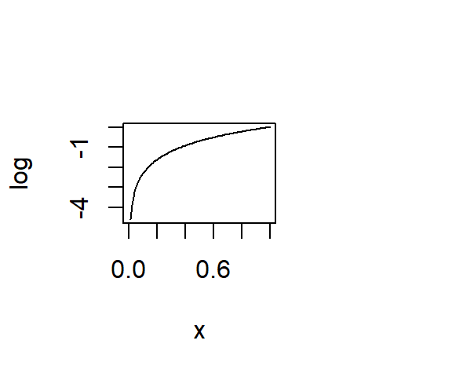

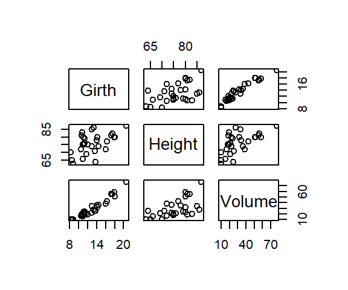

```r
layout(t(1:2), widths = c(3,1)); plot(log); plot(trees)
```

## Generic functions

`plot` is a *generic* function. Generic functions don’t do anything themselves – they call *methods*, which are tailored to the class.

```r
plot
```

```
## function (x, y, ...)
## UseMethod("plot")
## <bytecode: 0x06f63e20>
## <environment: namespace:graphics>
```

```r
methods("plot") # lists all types R knows how to plot
```

```
##  [1] plot.acf*           plot.data.frame*    plot.decomposed.ts*
##  [4] plot.default        plot.dendrogram*    plot.density*
##  [7] plot.ecdf           plot.factor*        plot.formula*
## [10] plot.function       plot.hclust*        plot.histogram*
## [13] plot.HoltWinters*   plot.isoreg*        plot.lm*
## [16] plot.medpolish*     plot.mlm*           plot.ppr*
## [19] plot.prcomp*        plot.princomp*      plot.profile.nls*
## [22] plot.raster*        plot.spec*          plot.stepfun
## [25] plot.stl*           plot.table*         plot.ts
## [28] plot.tskernel*      plot.TukeyHSD*
## see '?methods' for accessing help and source code
```

## Generic functions

To find the functions that apply to a class

```r
methods(class = "lm")
```

```
##  [1] add1           alias          anova          case.names     coerce
##  [6] confint        cooks.distance deviance       dfbeta         dfbetas
## [11] drop1          dummy.coef     effects        extractAIC     family
## [16] formula        hatvalues      influence      initialize     kappa
## [21] labels         logLik         model.frame    model.matrix   nobs
## [26] plot           predict        print          proj           qr
## [31] residuals      rstandard      rstudent       show           simulate
## [36] slotsFromS3    summary        variable.names vcov
## see '?methods' for accessing help and source code
```

## Generic functions

To see the code for a generic function, type `[function].[class]`

```r
dimnames.data.frame
```

```
## function (x)
## list(row.names(x), names(x))
## <bytecode: 0x09eb41b0>
## <environment: namespace:base>
```

## Naming conventions

Because of the `[function].[class]` syntax, naming variables with dots in them is discouraged.

```r
my.favourite.number <- exp(1)
my_favourite_number <- exp(1) # better
```

- Assignment using `=` is also discouraged: use `<-` instead. (Why?)
- google.github.io/styleguide/Rguide.xml is worth reading

## Help

There are many ways to get help with using functions or debugging code

1. The internet

[figure not shown]

## Help

1. `?fn` shows the documentation for `fn`…

[figure not shown]

## Help

1. `help.search("topic")` searches help pages for “topic”

[figure not shown]

## Examples

The documentation pages often show examples (`example(plot)`) and have demos (`demo(plotmath)`). `vignette()` opens longer worked examples that are great for playing with new packages.

[figure not shown]

## Keep in mind

- The user of a function assumes responsibility for giving arguments in the correct form
- arguments are ordered
  - Unnamed arguments are allocated as first arguments
  - Named arguments can be anywhere in ordering
- Not supplied arguments assume default value
  - Not supplying arguments without a default gives an error message

Don’t get bogged down in reading *all* the documentation – experiment and learn from your mistakes instead!

## Debugging

1. Stare at it until you identify the problem a.k.a. psychic debugging
2. Breakdown the components until you find the problem (bisection method converges linearly!)
3. `traceback()` – covered later in the course

## RStudio

- You can use R in a terminal window by typing ‘R’ (once it is installed)
- Alternative: RStudio
  - Strongly recommended!
    - interface for scripts, console, figures
    - multiple R sessions in different directories
    - Projects!
    - RMarkdown (integrating `R` and Markdown/LaTex)

## Workflow versus product

Your workflow:

- Your operating system
- Your code editor (e.g. RStudio)
- The name of your home directory (mine is `/Users/adwillis`)
- The code you ran yesterday
- The programs you have installed at this time

## Workflow versus product

Your product:

- The raw data
- The code that needs to be run on the raw data to get results
  - including dependencies
- The report that you produce at the end of your analysis

## Workflow versus product

“Any R script you write should be written assuming that it will be run from a fresh R process with working directory set to the project directory. It creates everything it needs, in its own workspace or folder, and it touches nothing it did not create…” – Jenny Bryan

## Workflow versus product

You must avoid hardwiring your workflow into your product!

- Every distinct intellectual unit you work on should have its own folder
  - every data analysis, every method, every research project, every class
- You can type `install_packages` into your console (that’s workflow!), but use `library` in a script (that’s product!)
  - Even better, throw a `warning` if the version that is installed is not the one you thought

## Workflow versus product

- Portable
  - other computers
  - robust to your own reorganisation
- Polite
  - Avoids overwriting or interfering with other projects

## Workflow versus product

[figure not shown]

## RStudio Projects

RStudio Projects are the implementation of this

- RStudio creates `myproj.Rproj`, which goes in your working directory for that project
- Double-click on your `Rproj` file to open a fresh RStudio instance in the correct working directory
  - Has the capacity to load your `RData`
  - Create a project with File -> New Project
- You can run multiple R sessions using multiple RStudio Projects at once

## Modern statistical computing

If any of this seems like overkill

- Cut down 1000 lines to 80 lines with `tidyverse`
  - Amy 2017 >> Amy 2013
- “I had to change exactly one character to redo all of my simulations”
  - Bryan on the `simulator`
- “I didn’t know you could run multiple R sessions at once”
  - Conversation with a (unnamed) fifth year
- “Could you rerun the entire analysis with this patient added?”
  - The ideal answer is “Yes!”
  - *This will happen to you*

## Break

## Pop quiz

What is the distribution of the median of 51 exponentially-distributed random variables with rate = 1?

How could we use computing power to help us?

## Avoiding math with computers

To understand the distribution of the median of 51 exponentially-distributed random variables with rate = 1, we can

- Draw 51 Exp(1) random variables, calculate their median
- Do this again, and again, and again…

We can use the collection of medians to calculate summary statistics, draw histograms, do hypothesis testing…

## Avoiding math with computers…

… and learning how to write loops in the process

```r
simulations <- 10000
many_medians <- vector("numeric", simulations)
set.seed(171005)
for (i in 1:simulations) {
  my_sample <- rexp(n = 51, rate = 1)
  many_medians[i] <- median(my_sample)
}
```

What is the value of `many_medians` if `i = 5` triggers an error?

## Avoiding math with computers

```r
mean(many_medians) # actually: 0.70286
```

```
## [1] 0.7012355
```

```r
var(many_medians) # actually: 0.01978
```

```
## [1] 0.01985761
```

We just calculated the moments of an intractable distribution using computing!

## Avoiding math with computers

We could work out almost anything about the sample median in this way!

The distribution of the median of 51 Exp(1) random variables:

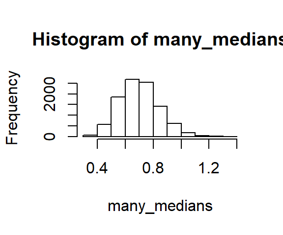

```r
hist(many_medians)
```

## Reproducible simulations

```r
set.seed(9)
rexp(4)
```

```
## [1] 1.403092 1.479229 1.255778 1.170410
```

```r
rexp(4)
```

```
## [1] 0.337385913 0.005871764 0.897366012 0.971816242
```

```r
set.seed(9)
rexp(4)
```

```
## [1] 1.403092 1.479229 1.255778 1.170410
```

## A note on history

Why are permutation/resampling approaches to data analysis modern?

## A note on history

[figure not shown]

## Possibly containing errors?

[figure not shown]

## Difficult to follow

[figure not shown]

## Better just buy a sudoku book

[figure not shown]

## Structure of a for loop

`for()` loops are not terrible, but watch out:

- First make an empty object of the correct dimension (e.g. vector, matrix, data frame) and *then* fill it in
  - Don’t forget to store the output of each iteration!
- For large loops and objects, growing the output is a big slowdown
  - This is because of the way that memory is handled in R

## A special set up

The only use of the index `i` was for storage.

```r
simulations <- 10000
many_medians <- vector("numeric", simulations)
set.seed(171005)
for (i in 1:simulations) {
  my_sample <- rexp(n = 51, rate = 1)
  many_medians[i] <- median(my_sample)
}
```

## A special set up

Since we are merely doing the same thing again and again, let’s use a new function to take care of all of the admin

```r
set.seed(171005)
many_medians <- replicate(simulations,
                          median(rexp(n = 51, rate = 1)))
```

The second argument to `replicate()` is the expression you want replicated

## Loop indices

The index of our loop (`i`) does not need to be a vector

```r
str(airquality) # a built-in dataset
```

```
## 'data.frame':    153 obs. of  6 variables:
##  $ Ozone  : int  41 36 12 18 NA 28 23 19 8 NA ...
##  $ Solar.R: int  190 118 149 313 NA NA 299 99 19 194 ...
##  $ Wind   : num  7.4 8 12.6 11.5 14.3 14.9 8.6 13.8 20.1 8.6 ...
##  $ Temp   : int  67 72 74 62 56 66 65 59 61 69 ...
##  $ Month  : int  5 5 5 5 5 5 5 5 5 5 ...
##  $ Day    : int  1 2 3 4 5 6 7 8 9 10 ...
```

## Loop indices

The index of our loop (`i`) does not need to be a vector

```r
for (month in unique(airquality$Month)) {
  print(mean(airquality$Ozone[airquality$Month == month],
   na.rm = TRUE)) # prints but doesn't store
}
```

```
## [1] 23.61538
## [1] 29.44444
## [1] 59.11538
## [1] 59.96154
## [1] 31.44828
```

We’ll see better ways to do this with `dplyr`

## Looping over variables: `apply()`

```r
apply(X=airquality, MARGIN=2, FUN=mean, na.rm=TRUE)
```

```
##      Ozone    Solar.R       Wind       Temp      Month        Day
##  42.129310 185.931507   9.957516  77.882353   6.993464  15.803922
```

- `X`: an array, usually a matrix or data frame
- `MARGIN`: the direction. `MARGIN = 1` applies the function to each row, `MARGIN = 2` applies the function to each column.
- `FUN`: the function to be applied
- Any other arguments to be passed to `FUN`

## Defining your own functions

```r
mean_and_sd <- function(x) {
  c(mean = mean(x), sd = sd(x))
}
apply(airquality, 2, mean_and_sd)
```

```
##      Ozone Solar.R     Wind     Temp    Month      Day
## mean    NA      NA 9.957516 77.88235 6.993464 15.80392
## sd      NA      NA 3.523001  9.46527 1.416522  8.86452
```

## Defining your own functions as wrappers

```r
mean_and_sd <- function(x, ...) { c(mean = mean(x, ...),
        sd = sd(x, ...)) }
apply(airquality, 2, mean_and_sd, na.rm = TRUE)
```

```
##         Ozone   Solar.R     Wind     Temp    Month      Day
## mean 42.12931 185.93151 9.957516 77.88235 6.993464 15.80392
## sd   32.98788  90.05842 3.523001  9.46527 1.416522  8.86452
```

Debugging code with ellipses can be tricky! Be cautious…

## Homework 1 and next week

- Slides and Homework 1:
  - github.com/adw96/biostat561/lecture1
- Homework 1 is due next Wednesday at 2:30 p.m.
  - github.com/adw96/biostat561/lecture1/homework1.pdf
- Complete Question 0 by next Monday (office hours!)
- Submission via github classroom (instructions included):
  - classroom.github.com/classrooms/48962297-biostat561-2019

## My personal computing setup

- Mac user
- R via RStudio
  - R packages for all methods development
  - Rscript (if I have to)
- Atom as my primary text editor
  - Markdown, RMarkdown, shell scripts, data files…
  - works well with git
  - also `vi`
- Manage collaborations via GitHub wherever possible
  - Sometimes with overleaf
- Automate tasks using shell scripts (occasionally R)
- Avoid Dropbox and Microsoft Word as much is possible
- Avoid typing and mousing in favour of voicecoding and eyetracking
- Favourite programs include RSIGuard and vimium